# PISA Data Exploration

I will now investigate relationships between variables and students' learning time per week.

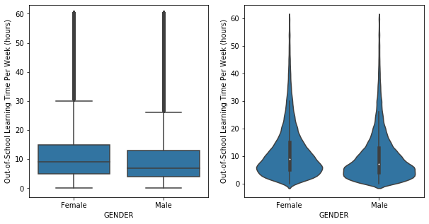

```python
# Whether gender type has any effect on students' learning time per week

plt.figure(figsize=[10,5])
base_color = sb.color_palette()[0]

plt.subplot(1, 2, 1)
ax1=sb.boxplot(data = Pisa_result, x = 'GENDER', y = 'OUTHOURS', color = base_color);
ax1.set_ylabel("Out-of-School Learning Time Per Week (hours)");

plt.subplot(1, 2, 2)
ax2=sb.violinplot(data = Pisa_result, x = 'GENDER', y = 'OUTHOURS', color = base_color);
ax2.set_ylabel("Out-of-School Learning Time Per Week (hours)");
```

Interestingly, in this dataset female students report more Out-of-School Learning Time Per Week (hours) than their male counterparts.

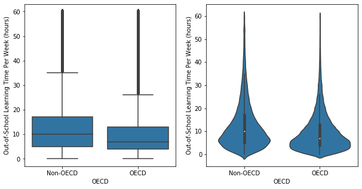

```python
# Whether country type has any effect on students' learning time per week

plt.figure(figsize=[10,5])
base_color = sb.color_palette()[0]

plt.subplot(1, 2, 1)
ax1=sb.boxplot(data = Pisa_result, x = 'OECD', y = 'OUTHOURS', color = base_color);
ax1.set_ylabel("Out-of-School Learning Time Per Week (hours)");

plt.subplot(1, 2, 2)
ax2=sb.violinplot(data = Pisa_result, x = 'OECD', y = 'OUTHOURS', color = base_color)
ax2.set_ylabel("Out-of-School Learning Time Per Week (hours)");
```

In this dataset, students from Non-OECD countries report longer Out-of-School Learning Time Per Week (hours)compared to their OECD peers. This fact is expecially interesting, when we recall that in earlier analysis students' sense of belonging to school is slightly higher in OECD countries.

I am then interested in finding out whether can strong sense of belonging to school motivate students to commit more Out-of-School learning time per week? Do math teaching strategies have positive impact on students' math study time?

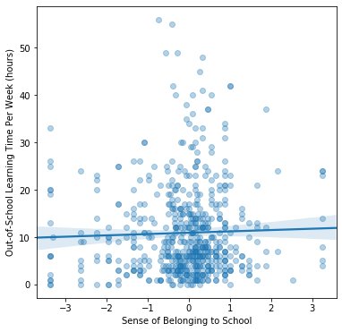

```python
# plot 2000 pisa sample data so that plots are clearer and they render faster

plt.figure(figsize=[6,6])
base_color = sb.color_palette()[0]

samples = np.random.choice(Pisa_result.shape[0], 2000, replace = False)
Pisa_sample = Pisa_result.loc[samples,:]
sb.regplot(data = Pisa_sample, x = 'ANCBELONG', y = "OUTHOURS",scatter_kws = {'alpha' : 1/3});

plt.xlabel("Sense of Belonging to School")
plt.ylabel("Out-of-School Learning Time Per Week (hours)");
```

A weak positive correlation is observed between these two variables, indicating that higher sense of belonging to school can slightly motivate students to study harder.

[figure not shown]

```python
Math_teaching_strategy=["ANCCOGACT","ANCSTUDREL","ANCMTSUP"]
fig, ax = plt.subplots(nrows = 3,figsize = [8,14])
base_color = sb.color_palette()[0]

for i in range(len(Math_teaching_strategy)):
    var = Math_var[i]
    sb.regplot(data = Pisa_sample, x = var, y = "MMINS",ax=ax[i],color=base_color, scatter_kws = {'alpha' : 1/3});
    ax[i].set_xlabel('{}'.format(Ab_dict[var]))
    ax[i].set_ylabel("Math Learning Time Per Week (mins)");
```

### Talk about some of the relationships you observed in this part of the investigation. How did the feature(s) of interest vary with other features in the dataset?

It can be observed that students' attitude towards school learning and teacher-student relations have very strong interactions with their sense of belonging to school. Interestingly, students from OECD countries have a bit higher sense of belonging to school compared to peers from Non-OECD countries.So did female students in this dataset.

However, students' economic, social and cultural status don't seem to have obvious effect on their sense of belonging to school.

### Did you observe any interesting relationships between the other features (not the main feature(s) of interest)?

Unlike what's expected, there is only very weak positive correlation between students' sense of belonging to school and their out-of-school learning time, same between math teaching strategies and students' math study time.

However, I do notice that female students in this dataset report more Out-of-School learning time per week (hours) than their male counterparts. And students from Non-OECD countries report longer Out-of-School learning time per week (hours)compared to their OECD peers.

## Multivariate Exploration

The main thing I want to explore in this part of the analysis is how the two categorical measures of gender and OECD play into the relationship between students' attitude and sense of belonging to school.

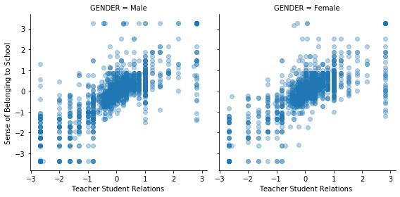

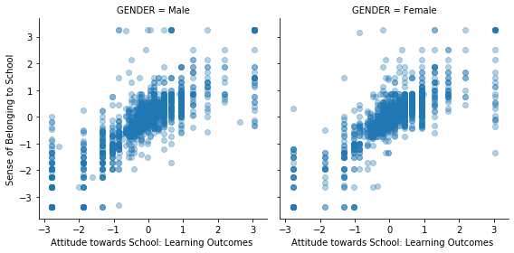

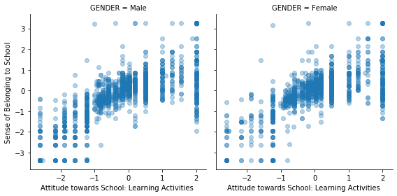

```python
# plot 5000 pisa sample data so that plots are clearer and they render faster

vars_target=["ANCSTUDREL","ANCATSCHL","ANCATTLNACT"]
samples = np.random.choice(Pisa_result.shape[0], 5000, replace = False)
Pisa_sample = Pisa_result.loc[samples,:]

#g=sb.FacetGrid(data = Pisa_sample, col = 'GENDER',size=4)
for i in range(len(vars_target)):
    var=vars_target[i]
    g=sb.FacetGrid(data = Pisa_sample, col = 'GENDER',size=4)
    g.map(plt.scatter, var, 'ANCBELONG',alpha = 1/3)
    g.set_xlabels(Ab_dict[var].split("(")[0])
    g.set_ylabels("Sense of Belonging to School")
```

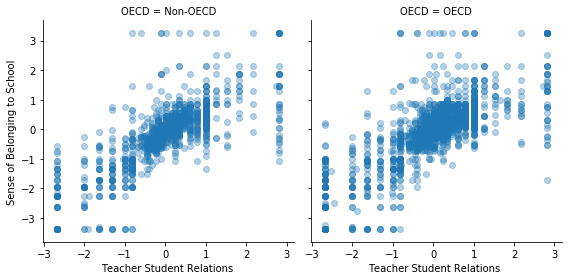

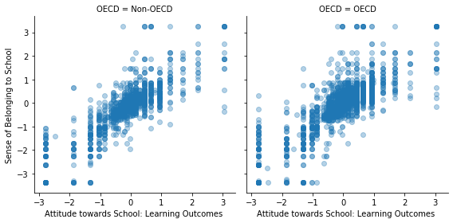

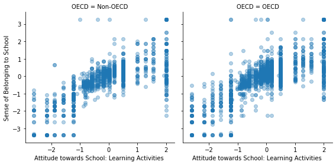

```python
vars_target=["ANCSTUDREL","ANCATSCHL","ANCATTLNACT"]
samples = np.random.choice(Pisa_result.shape[0], 5000, replace = False)
Pisa_sample = Pisa_result.loc[samples,:]

for i in range(len(vars_target)):
    var=vars_target[i]
    g=sb.FacetGrid(data = Pisa_sample, col = 'OECD',size=4)
    g.map(plt.scatter, var, 'ANCBELONG',alpha = 1/3)
    g.set_xlabels(Ab_dict[var].split("(")[0])
    g.set_ylabels("Sense of Belonging to School")
```

As demonstrated by above plottings, this strong positive correlation between students attitude towards school learning, teacher-student relations and students' sense of belonging to school is universal across all countries in or not in OECD as well as both genders.

I also want to explore in this section whether some combined factors can possibly affect students' out-of-school learning time.

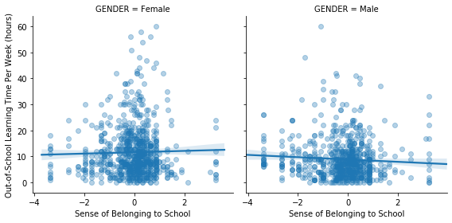

```python
samples = np.random.choice(Pisa_result.shape[0], 5000, replace = False)
Pisa_sample = Pisa_result.loc[samples,:]

g=sb.FacetGrid(data = Pisa_sample, col = 'GENDER',size=4)
g.map(sb.regplot, 'ANCBELONG',"OUTHOURS",scatter_kws = {'alpha' : 1/3})
g.set_xlabels("Sense of Belonging to School")
g.set_ylabels("Out-of-School Learning Time Per Week (hours)");
```

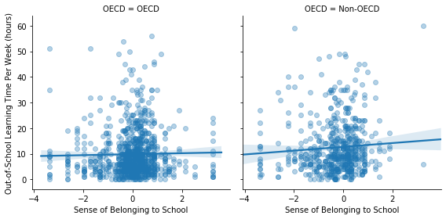

```python
samples = np.random.choice(Pisa_result.shape[0], 5000, replace = False)
Pisa_sample = Pisa_result.loc[samples,:]

g=sb.FacetGrid(data = Pisa_sample, col = 'OECD',size=4)
g.map(sb.regplot, 'ANCBELONG',"OUTHOURS",scatter_kws = {'alpha' : 1/3})
g.set_xlabels("Sense of Belonging to School")
g.set_ylabels("Out-of-School Learning Time Per Week (hours)");
```

Interestingly, for female students in this dataset, there is a slightly stronger interaction between students' sense of belonging to school and out-of-school study time. The same positive correlation is also stronger for students in Non-OECD countries.

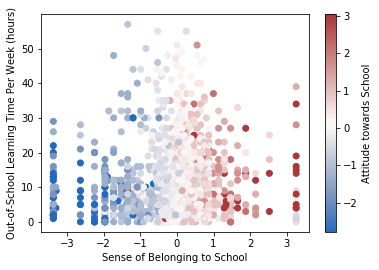

```python
#Can combined factors of students' sense of belonging to school and attitude towards learning can affect their out-of-school learning time?

samples = np.random.choice(Pisa_result.shape[0], 5000, replace = False)
Pisa_sample = Pisa_result.loc[samples,:]

plt.figure(figsize=[6,4])
plt.scatter(data = Pisa_sample, x = 'ANCBELONG', y = 'OUTHOURS', c = 'ANCATSCHL',cmap = 'vlag')
plt.xlabel("Sense of Belonging to School")
plt.ylabel("Out-of-School Learning Time Per Week (hours)")
cb=plt.colorbar()
cb.set_label("Attitude towards School");
```

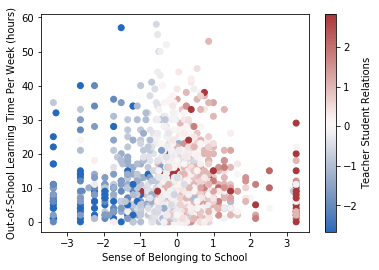

```python
#Can combined factors of students' sense of belonging to school and teacher-student relations can affect their out-of-school learning time?

samples = np.random.choice(Pisa_result.shape[0], 5000, replace = False)
Pisa_sample = Pisa_result.loc[samples,:]

plt.figure(figsize=[6,4])
plt.scatter(data = Pisa_sample, x = 'ANCBELONG', y = 'OUTHOURS', c = 'ANCSTUDREL',cmap = 'vlag')
plt.xlabel("Sense of Belonging to School")
plt.ylabel("Out-of-School Learning Time Per Week (hours)")
cb=plt.colorbar()
cb.set_label("Teacher Student Relations");
```

The weak positive correlation between students' sense of belonging to school and their out-of-school learning time can be slightly strengthed when including the factors of attitude towards school and teacher student relations.

### Talk about some of the relationships you observed in this part of the investigation. Were there features that strengthened each other in terms of looking at your feature(s) of interest?

As well demonstrated by this section, the strong positive correlation between students attitude towards school learning, teacher-student relations and students' sense of belonging to school is universal across all countries in or not in OECD as well as both genders.

The weak positive correlation between students' sense of belonging to school and their out-of-school learning time can be slightly strengthed when including the factors of attitude towards school and teacher student relations. However, no solid story could be told from this perspective.

### Were there any interesting or surprising interactions between features?

Interestingly, for female students in this dataset, there is a slightly stronger interaction between students' sense of belonging to school and out-of-school study time. The same positive correlation is also stronger for students in Non-OECD countries. However, no solid story could be told from this perspective.